# Introduction to R

- About this course
- Acknowledgements
- Introduction to R
- About R
- R, RStudio set up
- A first look to R session
- R objects
- R objects
- Data Import
- Data Import and Export
- Data manipulation with dplyr
- Introduction to dplyr
- Verb functions
- Group Data and Chain Verbs
- Data visualization with ggplot2
- Graphs with ggplot2
- Data Analysis
- Statistical models with R
- R Development
- Writing R functions
- R Markdown

# Verb functions

`dplyr` aims to provide a function for each basic verb of data manipulating.

All these functions are very similar:

- the first argument is a data frame;
- the subsequent arguments describe what to do with it, and you can refer to columns in the data frame directly without using $;
- the result is a new data frame.

Together these properties make it easy to chain together multiple simple steps to achieve a complex result.

These five functions provide the basis of a language of data manipulation. At the most basic level, you can only alter a tidy data frame in five useful ways:

1. select variables of interest: `select()`;
2. filter records of interest: `filter()`;
3. reorder the rows: `arrange()`;
4. add new variables that are functions of existing variables: `mutate()`;
5. collapse many values to a summary: `summarise()`.

In the following examples we will refer to `bank` data set which contains information about a direct marketing campaigns of a Portuguese banking institution based on phone calls.

```r
data(bank)
bank <- tbl_df(bank)
```

# `select()`

Often you work with large datasets with many columns where only a few are actually of interest to you.

`select()` allows you to rapidly zoom in on a useful subset of columns.

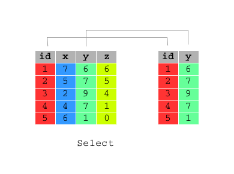

The first argument is the name of the data frame, and the second and subsequent are the name of column/s of that data frame you want to select:

```r
# Select columns: year, month and day of bank data frame
select(bank, year, month, day)
```

```
## Source: local data frame [45,211 x 3]
##
##     year  month   day
##    (int) (fctr) (int)
## 1   2008    may     5
## 2   2008    may     5
## 3   2008    may     5
## 4   2008    may     5
## 5   2008    may     5
## 6   2008    may     5
## 7   2008    may     5
## 8   2008    may     5
## 9   2008    may     5
## 10  2008    may     5
## ..   ...    ...   ...
```

```r
# Select columns: year, month and day of bank data frame
select(bank, year:day)
```

```
## Source: local data frame [45,211 x 3]
##
##     year  month   day
##    (int) (fctr) (int)
## 1   2008    may     5
## 2   2008    may     5
## 3   2008    may     5
## 4   2008    may     5
## 5   2008    may     5
## 6   2008    may     5
## 7   2008    may     5
## 8   2008    may     5
## 9   2008    may     5
## 10  2008    may     5
## ..   ...    ...   ...
```

```r
# Select all columns of bank data frame apart from: year, month and day
select(bank, -(year:day))
```

```
## Source: local data frame [45,211 x 17]
##
##       id   age          job  marital education default balance housing
##    (int) (int)       (fctr)   (fctr)    (fctr)  (fctr)   (int)  (fctr)
## 1      1    58   management  married  tertiary      no    2143     yes
## 2      2    44   technician   single secondary      no      29     yes
## 3      3    33 entrepreneur  married secondary      no       2     yes
## 4      4    47  blue-collar  married   unknown      no    1506     yes
## 5      5    33      unknown   single   unknown      no       1      no
## 6      6    35   management  married  tertiary      no     231     yes
## 7      7    28   management   single  tertiary      no     447     yes
## 8      8    42 entrepreneur divorced  tertiary     yes       2     yes
## 9      9    58      retired  married   primary      no     121     yes
## 10    10    43   technician   single secondary      no     593     yes
## ..   ...   ...          ...      ...       ...     ...     ...     ...
## Variables not shown: loan (fctr), contact (fctr), date (time), duration
##   (int), campaign (int), pdays (int), previous (int), poutcome (fctr), y
##   (fctr)
```

You can rename variables with `select()` by using named arguments:

```r
# Rename id variable as ID
select(bank, ID = id)
```

```
## Source: local data frame [45,211 x 1]
##
##       ID
##    (int)
## 1      1
## 2      2
## 3      3
## 4      4
## 5      5
## 6      6
## 7      7
## 8      8
## 9      9
## 10    10
## ..   ...
```

# `filter()`

`filter()` allows you to select a subset of the rows of a data frame.

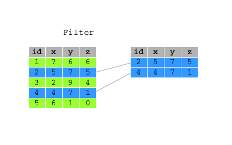

The first argument is the name of the data frame, and the second and subsequent are filtering expressions evaluated in the context of that data frame.

For example, you can select all calls made to students whit balance above 20,000:

```r
filter(bank, job == "student", balance > 20000)
```

```
## Source: local data frame [3 x 20]
##
##      id   age     job marital education default balance housing   loan
##   (int) (int)  (fctr)  (fctr)    (fctr)  (fctr)   (int)  (fctr) (fctr)
## 1 31125    24 student  single secondary      no   23878      no     no
## 2 39536    24 student  single secondary      no   23878      no     no
## 3 41923    27 student  single  tertiary      no   24025      no     no
## Variables not shown: contact (fctr), day (int), month (fctr), year (int),
##   date (time), duration (int), campaign (int), pdays (int), previous
##   (int), poutcome (fctr), y (fctr)
```

`filter()` allows you to give it any number of filtering conditions which are joined together with `&` and/or the other operators.

```r
# Select all calls made to student of 18 years
filter(bank, age == 18 & job == "student")
```

```
## Source: local data frame [12 x 20]
##
##       id   age     job marital education default balance housing   loan
##    (int) (int)  (fctr)  (fctr)    (fctr)  (fctr)   (int)  (fctr) (fctr)
## 1  40737    18 student  single   primary      no    1944      no     no
## 2  40745    18 student  single   unknown      no     108      no     no
## 3  40888    18 student  single   primary      no     608      no     no
## 4  41223    18 student  single   unknown      no      35      no     no
## 5  41253    18 student  single secondary      no       5      no     no
## 6  41274    18 student  single   unknown      no       3      no     no
## 7  41488    18 student  single   unknown      no     108      no     no
## 8  42147    18 student  single secondary      no     156      no     no
## 9  42275    18 student  single   primary      no     608      no     no
## 10 42955    18 student  single   unknown      no     108      no     no
## 11 43638    18 student  single   unknown      no     348      no     no
## 12 44645    18 student  single   unknown      no     438      no     no
## Variables not shown: contact (fctr), day (int), month (fctr), year (int),
##   date (time), duration (int), campaign (int), pdays (int), previous
##   (int), poutcome (fctr), y (fctr)
```

```r
# Select all calls made to people of 18 or years
filter(bank, age == 18 | age == 95)
```

```
## Source: local data frame [14 x 20]
##
##       id   age     job  marital education default balance housing   loan
##    (int) (int)  (fctr)   (fctr)    (fctr)  (fctr)   (int)  (fctr) (fctr)
## 1  33700    95 retired divorced   primary      no    2282      no     no
## 2  40737    18 student   single   primary      no    1944      no     no
## 3  40745    18 student   single   unknown      no     108      no     no
## 4  40888    18 student   single   primary      no     608      no     no
## 5  41223    18 student   single   unknown      no      35      no     no
## 6  41253    18 student   single secondary      no       5      no     no
## 7  41274    18 student   single   unknown      no       3      no     no
## 8  41488    18 student   single   unknown      no     108      no     no
## 9  41664    95 retired  married secondary      no       0      no     no
## 10 42147    18 student   single secondary      no     156      no     no
## 11 42275    18 student   single   primary      no     608      no     no
## 12 42955    18 student   single   unknown      no     108      no     no
## 13 43638    18 student   single   unknown      no     348      no     no
## 14 44645    18 student   single   unknown      no     438      no     no
## Variables not shown: contact (fctr), day (int), month (fctr), year (int),
##   date (time), duration (int), campaign (int), pdays (int), previous
##   (int), poutcome (fctr), y (fctr)
```

`filter()` can be used also with `%in%` to establish conditions under which filter:

```r
# Select all calls made to people of 18 or years
filter(bank, age %in% c(18,95))
```

```
## Source: local data frame [14 x 20]
##
##       id   age     job  marital education default balance housing   loan
##    (int) (int)  (fctr)   (fctr)    (fctr)  (fctr)   (int)  (fctr) (fctr)
## 1  33700    95 retired divorced   primary      no    2282      no     no
## 2  40737    18 student   single   primary      no    1944      no     no
## 3  40745    18 student   single   unknown      no     108      no     no
## 4  40888    18 student   single   primary      no     608      no     no
## 5  41223    18 student   single   unknown      no      35      no     no
## 6  41253    18 student   single secondary      no       5      no     no
## 7  41274    18 student   single   unknown      no       3      no     no
## 8  41488    18 student   single   unknown      no     108      no     no
## 9  41664    95 retired  married secondary      no       0      no     no
## 10 42147    18 student   single secondary      no     156      no     no
## 11 42275    18 student   single   primary      no     608      no     no
## 12 42955    18 student   single   unknown      no     108      no     no
## 13 43638    18 student   single   unknown      no     348      no     no
## 14 44645    18 student   single   unknown      no     438      no     no
## Variables not shown: contact (fctr), day (int), month (fctr), year (int),
##   date (time), duration (int), campaign (int), pdays (int), previous
##   (int), poutcome (fctr), y (fctr)
```

An other example is:

```r
# Select all calls made to people whose jos is admin. or technician
filter(bank, job %in% c("admin.","technician"))
```

```
## Source: local data frame [12,768 x 20]
##
##       id   age        job  marital education default balance housing
##    (int) (int)     (fctr)   (fctr)    (fctr)  (fctr)   (int)  (fctr)
## 1      2    44 technician   single secondary      no      29     yes
## 2     10    43 technician   single secondary      no     593     yes
## 3     11    41     admin. divorced secondary      no     270     yes
## 4     12    29     admin.   single secondary      no     390     yes
## 5     13    53 technician  married secondary      no       6     yes
## 6     14    58 technician  married   unknown      no      71     yes
## 7     17    45     admin.   single   unknown      no      13     yes
## 8     26    44     admin.  married secondary      no    -372     yes
## 9     30    36 technician   single secondary      no     265     yes
## 10    31    57 technician  married secondary      no     839      no
## ..   ...   ...        ...      ...       ...     ...     ...     ...
## Variables not shown: loan (fctr), contact (fctr), day (int), month (fctr),
##   year (int), date (time), duration (int), campaign (int), pdays (int),
##   previous (int), poutcome (fctr), y (fctr)
```

```r
# Select all calls made to people whose jos is admin. or technician
filter(bank, job == "admin." | job == "technician")
```

```
## Source: local data frame [12,768 x 20]
##
##       id   age        job  marital education default balance housing
##    (int) (int)     (fctr)   (fctr)    (fctr)  (fctr)   (int)  (fctr)
## 1      2    44 technician   single secondary      no      29     yes
## 2     10    43 technician   single secondary      no     593     yes
## 3     11    41     admin. divorced secondary      no     270     yes
## 4     12    29     admin.   single secondary      no     390     yes
## 5     13    53 technician  married secondary      no       6     yes
## 6     14    58 technician  married   unknown      no      71     yes
## 7     17    45     admin.   single   unknown      no      13     yes
## 8     26    44     admin.  married secondary      no    -372     yes
## 9     30    36 technician   single secondary      no     265     yes
## 10    31    57 technician  married secondary      no     839      no
## ..   ...   ...        ...      ...       ...     ...     ...     ...
## Variables not shown: loan (fctr), contact (fctr), day (int), month (fctr),
##   year (int), date (time), duration (int), campaign (int), pdays (int),
##   previous (int), poutcome (fctr), y (fctr)
```

# `arrange()`

Function `arrange()` reorders a data frame by one or more variables. If you provide more than one column name, each additional column will be used to break ties in the values of preceding columns:

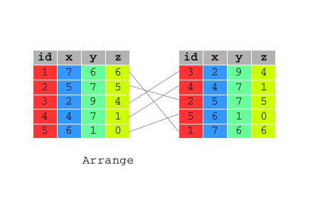

The first argument is the name of the data frame, and the second and subsequent are the name of columns of that data frame you want to order by.  
You may want to order the `bank` data frame by the balance of the account in ascending order:

```r
arrange(bank, balance)
```

```
## Source: local data frame [45,211 x 20]
##
##       id   age           job  marital education default balance housing
##    (int) (int)        (fctr)   (fctr)    (fctr)  (fctr)   (int)  (fctr)
## 1  12910    26   blue-collar   single secondary     yes   -8019      no
## 2  15683    49    management  married  tertiary     yes   -6847      no
## 3  38737    60    management divorced  tertiary      no   -4057     yes
## 4   7414    43    management  married  tertiary     yes   -3372     yes
## 5   1897    57 self-employed  married  tertiary     yes   -3313     yes
## 6  32714    39 self-employed  married  tertiary      no   -3058     yes
## 7  18574    40    technician  married  tertiary     yes   -2827     yes
## 8  31510    52    management  married  tertiary      no   -2712     yes
## 9  25120    49   blue-collar   single   primary     yes   -2604     yes
## 10 14435    51    management divorced  tertiary      no   -2282     yes
## ..   ...   ...           ...      ...       ...     ...     ...     ...
## Variables not shown: loan (fctr), contact (fctr), day (int), month (fctr),
##   year (int), date (time), duration (int), campaign (int), pdays (int),
##   previous (int), poutcome (fctr), y (fctr)
```

or in descending order by using function `desc()` within `arrange()`:

```r
arrange(bank, desc(balance))
```

```
## Source: local data frame [45,211 x 20]
##
##       id   age          job  marital education default balance housing
##    (int) (int)       (fctr)   (fctr)    (fctr)  (fctr)   (int)  (fctr)
## 1  39990    51   management   single  tertiary      no  102127      no
## 2  26228    59   management  married  tertiary      no   98417      no
## 3  42559    84      retired  married secondary      no   81204      no
## 4  43394    84      retired  married secondary      no   81204      no
## 5  41694    60      retired  married   primary      no   71188      no
## 6  19786    56   management divorced  tertiary      no   66721      no
## 7  21193    52  blue-collar  married   primary      no   66653      no
## 8  19421    59       admin.  married   unknown      no   64343      no
## 9  41375    32 entrepreneur   single  tertiary      no   59649      no
## 10 12927    56  blue-collar  married secondary      no   58932      no
## ..   ...   ...          ...      ...       ...     ...     ...     ...
## Variables not shown: loan (fctr), contact (fctr), day (int), month (fctr),
##   year (int), date (time), duration (int), campaign (int), pdays (int),
##   previous (int), poutcome (fctr), y (fctr)
```

You can order a data frame by one or more than one variables.

Ordering data frame bank by `age` first and descending `ballance` afterward requires:

```r
arrange(bank, age , desc(balance))
```

```
## Source: local data frame [45,211 x 20]
##
##       id   age     job marital education default balance housing   loan
##    (int) (int)  (fctr)  (fctr)    (fctr)  (fctr)   (int)  (fctr) (fctr)
## 1  40737    18 student  single   primary      no    1944      no     no
## 2  40888    18 student  single   primary      no     608      no     no
## 3  42275    18 student  single   primary      no     608      no     no
## 4  44645    18 student  single   unknown      no     438      no     no
## 5  43638    18 student  single   unknown      no     348      no     no
## 6  42147    18 student  single secondary      no     156      no     no
## 7  40745    18 student  single   unknown      no     108      no     no
## 8  41488    18 student  single   unknown      no     108      no     no
## 9  42955    18 student  single   unknown      no     108      no     no
## 10 41223    18 student  single   unknown      no      35      no     no
## ..   ...   ...     ...     ...       ...     ...     ...     ...    ...
## Variables not shown: contact (fctr), day (int), month (fctr), year (int),
##   date (time), duration (int), campaign (int), pdays (int), previous
##   (int), poutcome (fctr), y (fctr)
```

# `mutate()`

As well as selecting from the set of existing columns, it’s often useful to add new columns that are functions of existing columns. This is the job of `mutate()`:

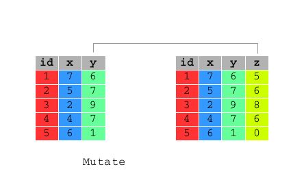

The first argument is the name of the data frame, and the second and subsequent are expressions for creating new columns to add to that data frame or for modifying the existing ones:

```r
df <- data.frame(x = 1:3, y = 3:1)

mutate(df, x1 = x+1)
```

```
##   x y x1
## 1 1 3  2
## 2 2 2  3
## 3 3 1  4
```

```r
mutate(df, x = x+1)
```

```
##   x y
## 1 2 3
## 2 3 2
## 3 4 1
```

```r
mutate(df, x = x+1, y = x+1)
```

```
##   x y
## 1 2 3
## 2 3 4
## 3 4 5
```

```r
mutate(df, x1 = x+1, y1 = x1+1)
```

```
##   x y x1 y1
## 1 1 3  2  3
## 2 2 2  3  4
## 3 3 1  4  5
```

```r
mutate(df, y1 = x+1, x1 = x+1)
```

```
##   x y y1 x1
## 1 1 3  2  2
## 2 2 2  3  3
## 3 3 1  4  4
```

```r
mutate(df, xx = x)
```

```
##   x y xx
## 1 1 3  1
## 2 2 2  2
## 3 3 1  3
```

`mutate()` allows you to refer to columns that you just created:

```r
mutate(bank, year_of_birth = year - age, year_of_birth_no_century = year_of_birth - 1900)
```

```
## Source: local data frame [45,211 x 22]
##
##       id   age          job  marital education default balance housing
##    (int) (int)       (fctr)   (fctr)    (fctr)  (fctr)   (int)  (fctr)
## 1      1    58   management  married  tertiary      no    2143     yes
## 2      2    44   technician   single secondary      no      29     yes
## 3      3    33 entrepreneur  married secondary      no       2     yes
## 4      4    47  blue-collar  married   unknown      no    1506     yes
## 5      5    33      unknown   single   unknown      no       1      no
## 6      6    35   management  married  tertiary      no     231     yes
## 7      7    28   management   single  tertiary      no     447     yes
## 8      8    42 entrepreneur divorced  tertiary     yes       2     yes
## 9      9    58      retired  married   primary      no     121     yes
## 10    10    43   technician   single secondary      no     593     yes
## ..   ...   ...          ...      ...       ...     ...     ...     ...
## Variables not shown: loan (fctr), contact (fctr), day (int), month (fctr),
##   year (int), date (time), duration (int), campaign (int), pdays (int),
##   previous (int), poutcome (fctr), y (fctr), year_of_birth (int),
##   year_of_birth_no_century (dbl)
```

# `summarise()`

The last verb is `summarise()`, which collapses a data frame to a single row.

The first argument is the name of the data frame, and the second and subsequent are summarising expressions.

```r
# Compute the mean of balance
summarise(bank, mean_balance = mean(balance, na.rm = TRUE))
```

```
## Source: local data frame [1 x 1]
##
##   mean_balance
##          (dbl)
## 1     1362.272
```

```r
# Compute the minimum and the maximum value of balance
summarise(bank, max_balance = max(balance, na.rm = TRUE), min_balance = min(balance, na.rm = TRUE))
```

```
## Source: local data frame [1 x 2]
##
##   max_balance min_balance
##         (int)       (int)
## 1      102127       -8019
```